# Lab 5 Insurance Costs

```python
import numpy as np
import pandas as pd
from plotnine import *
from sklearn.linear_model import LinearRegression
from sklearn.pipeline import Pipeline
from sklearn.metrics import r2_score
from sklearn.metrics import mean_absolute_error, r2_score, mean_squared_error
from sklearn.model_selection import train_test_split
from mizani.formatters import comma_format
from sklearn.preprocessing import PolynomialFeatures
```

# Part One: Data Exploration

```python
df = pd.read_csv("https://www.dropbox.com/s/bocjjyo1ehr5auz/insurance_costs_1.csv?dl=1")
df['smoking'] = df['smoker'].map({'yes': 1, 'no': 0})
df['male'] = df['sex'].map({'male': 1, 'female': 0})

df.head()
```

|  | age | sex | bmi | smoker | region | charges | smoking | male |
| --- | --- | --- | --- | --- | --- | --- | --- | --- |
| 0 | 19 | female | 27.900 | yes | southwest | 16884.92400 | 1 | 0 |
| 1 | 33 | male | 22.705 | no | northwest | 21984.47061 | 0 | 1 |
| 2 | 32 | male | 28.880 | no | northwest | 3866.85520 | 0 | 1 |
| 3 | 31 | female | 25.740 | no | southeast | 3756.62160 | 0 | 0 |
| 4 | 60 | female | 25.840 | no | northwest | 28923.13692 | 0 | 0 |

## Summaries

Observations

```python
pctSmoke = df["smoker"].value_counts(normalize=True).round(3)
pctSmoke.to_frame().reset_index()
```

|  | smoker | proportion |
| --- | --- | --- |
| 0 | no | 0.798 |
| 1 | yes | 0.202 |

```python
agedf = df["age"].describe().round(2)
agedf.to_frame("Age summary")
```

|  | Age summary |
| --- | --- |
| count | 431.00 |
| mean | 37.96 |
| std | 16.36 |
| min | 18.00 |
| 25% | 22.00 |
| 50% | 34.00 |
| 75% | 55.00 |
| max | 64.00 |

```python
smokerdf = df.groupby(["smoker","sex"])[["age","bmi","charges"]].mean().round(2)
smokerdf.reset_index()
```

|  | smoker | sex | age | bmi | charges |
| --- | --- | --- | --- | --- | --- |
| 0 | no | female | 37.80 | 30.96 | 7612.71 |
| 1 | no | male | 38.87 | 30.57 | 7431.59 |
| 2 | yes | female | 37.05 | 30.64 | 31246.86 |
| 3 | yes | male | 36.24 | 30.80 | 31068.16 |

```python
chargesdf = df["charges"].describe().round(2)
chargesdf.to_frame("Charges summary")
```

|  | Charges summary |
| --- | --- |
| count | 431.00 |
| mean | 12297.10 |
| std | 11876.53 |
| min | 1131.51 |
| 25% | 2710.44 |
| 50% | 9866.30 |
| 75% | 14510.87 |
| max | 55135.40 |

## 3 Plots

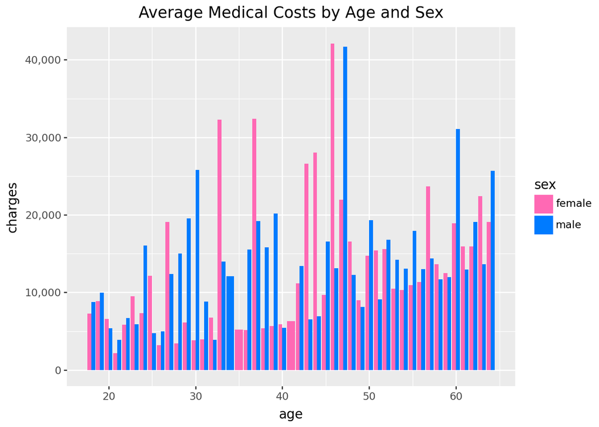

Figure 1

```python
avgdf = df.groupby(["age", "sex"], as_index=False)["charges"].mean()


(ggplot(avgdf,aes(x="age",y="charges",fill="sex"))
 + geom_bar(stat="identity",position="dodge")
 + scale_fill_manual(values=["#ff69b4","#007bff"])
 + scale_y_continuous(labels=comma_format())
 + labs(title="Average Medical Costs by Age and Sex")
)
```

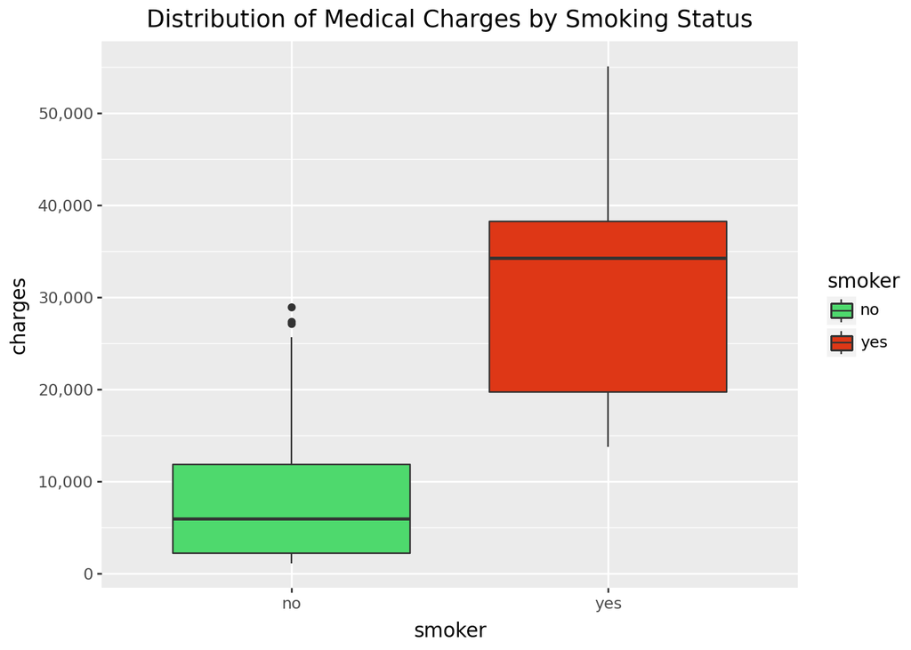

Figure 2

```python
(
    ggplot(df, aes(x="smoker", y="charges", fill="smoker"))
    + geom_boxplot()
    + scale_fill_manual(values=["#4ED96D", "#DE3716"])
    + scale_y_continuous(breaks=[0,10000,20000,30000,40000,50000],labels=comma_format())
    + labs(
        title="Distribution of Medical Charges by Smoking Status")
)
```

Figure 3 plots the BMI for all obersevations by the medical charges in a scatter plot, with smoking in red and no smoking in green. As BMI increases there seems to be no upward increases in medical charges for non-smokers. But for smokers, there does seem to be a positive correlation in BMI and medical charges as they both increase.

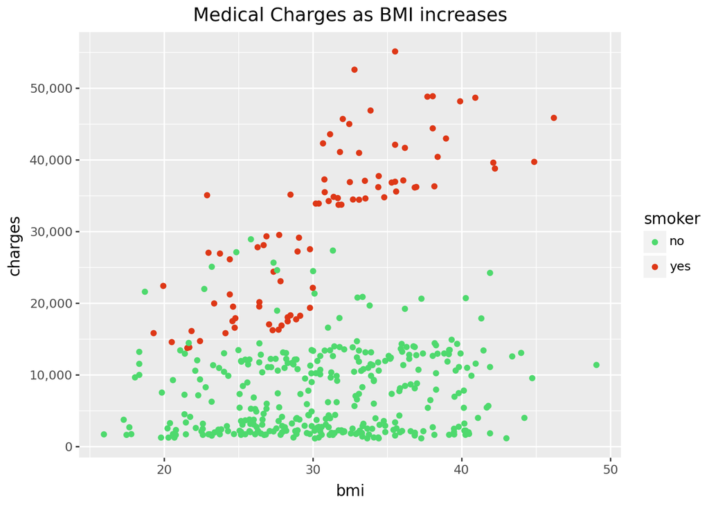

Figure 3

```python
(
    ggplot(df, aes(x="bmi", y="charges", color="smoker"))
    + geom_point()
    + scale_color_manual(values=["#4ED96D", "#DE3716"])
    + scale_y_continuous(breaks=[0,10000,20000,30000,40000,50000],labels=comma_format())
    + labs(
        title="Medical Charges as BMI increases",
    )
)
```

# Part Two: Simple Linear Models

## Model 1 Age

```python
Model1 = LinearRegression()


Model1.fit(
    X=df[["age"]],
    y=df["charges"]

)

names = ["Intercept","Age"]
value = [Model1.intercept_,Model1.coef_]


Model1_df = pd.DataFrame(value,names).astype(float).round(2)
Model1_df.index.name = "Model 1"
Model1_df
```

| Model 1 | 0 |
| --- | --- |
| Intercept | 3611.76 |
| Age | 228.80 |

For every year age increases, medical charges go up by $228.80 with the charges starting at $3,611.76.

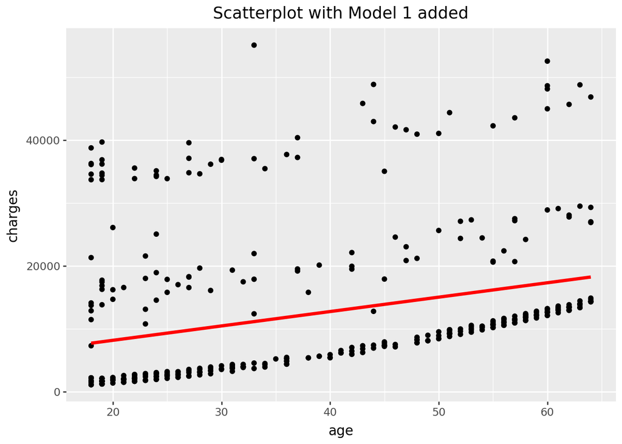

```python
x_pred1 = np.linspace(df['age'].min(), df['age'].max(), 100)
y_pred1 = Model1.predict(x_pred1.reshape(-1, 1))
reg1_df = pd.DataFrame({'x': x_pred1, 'y_pred': y_pred1})

(
ggplot(df,aes("age",y="charges"))
+ geom_point()
+ geom_line(reg1_df, aes('x', 'y_pred'), color='red',size=1.5)
+ labs(title="Scatterplot with Model 1 added")
)
```

Model 1 seems to fit some of the data where charges are small but overall does not do a good job at predicting charges.

## Model 2 Age + Sex

```python
Model2 = LinearRegression()

Model2.fit(
    X = df[["age","male"]],
    y=df["charges"]
)


names = ["Intercept","Age","Male"]
value = [Model2.intercept_,Model2.coef_[0],Model2.coef_[1]]

Model2_df = pd.DataFrame(value,names).astype(float).round(2)
Model2_df.index.name = "Model 2"
Model2_df
```

| Model 2 | 0 |
| --- | --- |
| Intercept | 3315.33 |
| Age | 228.43 |
| Male | 649.83 |

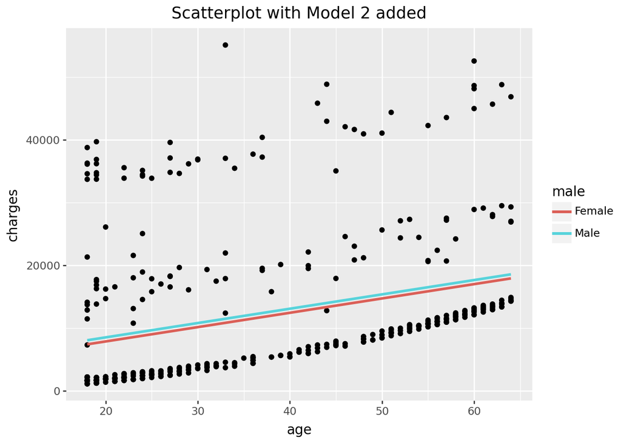

```python
x_pred2 = np.linspace(df['age'].min(), df['age'].max(), 100)

y_pred2_male0 = Model2.predict(pd.DataFrame({'age': x_pred2, 'male': 0}))
y_pred2_male1 = Model2.predict(pd.DataFrame({'age': x_pred2, 'male': 1}))

reg2_df = pd.DataFrame({
    'age': np.tile(x_pred2, 2),
    'y_pred': np.concatenate([y_pred2_male0, y_pred2_male1]),
    'male': ['Female'] * 100 + ['Male'] * 100
})

(
ggplot(df, aes(x='age', y='charges'))
+ geom_point()
+ geom_line(reg2_df, aes(x='age', y='y_pred', color='male'), size=1.2)
+ labs(title="Scatterplot with Model 2 added")
)
```

Model 2 seems to be very similar to Model 1 and the effect of sex seems to not shift the line vertically whether male or female.

## Model 3 Age + Smoker

```python
Model3 = LinearRegression()

Model3.fit(
    X = df[["age","smoking"]],
    y=df["charges"]
)


names = ["Intercept","Age","Smoking"]
value = [Model3.intercept_,Model3.coef_[0],Model3.coef_[1]]

Model3_df = pd.DataFrame(value,names).astype(float).round(2)
Model3_df.index.name = "Model 3"
Model3_df
```

| Model 3 | 0 |
| --- | --- |
| Intercept | -2166.85 |
| Age | 253.15 |
| Smoking | 24048.87 |

For every year increase, there is a $253.15 increase in charge and a $24048.87 premiumn if the benefiicary smokes.

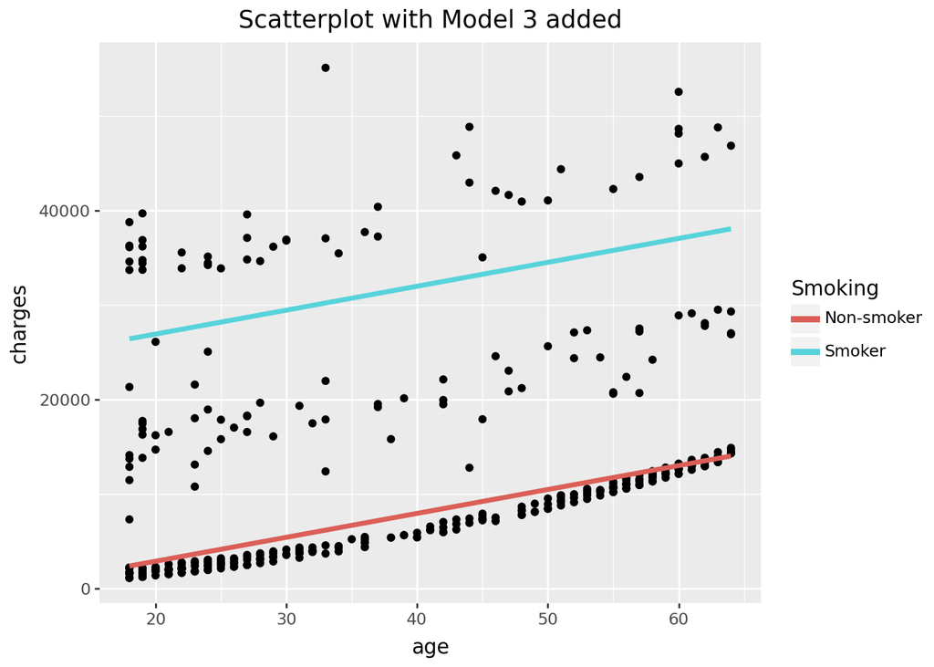

```python
x_pred3 = np.linspace(df['age'].min(), df['age'].max(), 100)

reg3_df = (
    pd.DataFrame({
        'age': np.tile(x_pred3, 2),
        'smoking': np.repeat([0, 1], repeats=len(x_pred3))
    })
)

reg3_df['y_pred3'] = Model3.predict(reg3_df[['age', 'smoking']])


reg3_df['smoking_label'] = reg3_df['smoking'].map({0: 'Non-smoker', 1: 'Smoker'})

(
ggplot(df, aes(x='age', y='charges'))
+ geom_point()
+ geom_line(reg3_df, aes(x='age', y='y_pred3', color='smoking_label'),size=1.5)
+ labs(title='Scatterplot with Model 3 added', color='Smoking')
)
```

Model 3 does a very good job at predicting 2 distinct trends in the data. Non-smoking correlates to the lower medical charges which have a highly correlated path, while Smokers have larger charges but very loosely correlated points.

## 4. Best model

Based on the plots it seems that Q3 which includes smoker as the predictor variable is much better at fitting the data.

```python
y_pred_Q1 = Model1.predict(df[['age']])
y_pred_Q2 = Model2.predict(df[['age', 'male']])
y_pred_Q3 = Model3.predict(df[['age', 'smoking']])

mse_Q1 = mean_squared_error(df['charges'], y_pred_Q1)
r2_Q1  = r2_score(df['charges'], y_pred_Q1)

mse_Q2 = mean_squared_error(df['charges'], y_pred_Q2)
r2_Q2  = r2_score(df['charges'], y_pred_Q2)

mse_Q3 = mean_squared_error(df['charges'], y_pred_Q3)
r2_Q3  = r2_score(df['charges'], y_pred_Q3)

metrics_df = pd.DataFrame({
    'Model': ["Model 1","Model 2", "Model 3"],
    'MSE': [mse_Q1,mse_Q2, mse_Q3],
    'R²': [r2_Q1,r2_Q2, r2_Q3]
}).round(3)

metrics_df['MSE'] = metrics_df['MSE'].apply(lambda x: f"{x:,.2f}")

metrics_df
```

|  | Model | MSE | R² |
| --- | --- | --- | --- |
| 0 | Model 1 | 126,739,267.91 | 0.099 |
| 1 | Model 2 | 126,633,939.68 | 0.100 |
| 2 | Model 3 | 33,719,831.47 | 0.760 |

Based on the R-squared and MSE, Model 3 is much better at predicting charges as its R2 score is higher at 0.76 and MSE is much lower at 33 million instead of 126 million.

# Part Three: Multiple Linear Models

## 1. Age and BMI

```python
Model4 = LinearRegression()

Model4.fit(
    X = df[["age","bmi"]],
    y=df["charges"]
)


names = ["Intercept","Age","BMI"]
value = [Model4.intercept_,Model4.coef_[0],Model4.coef_[1]]

Model4_df = pd.DataFrame(value,names).astype(float).round(2)
Model4_df.index.name = "Model 4"
Model4_df
```

| Model 4 | 0 |
| --- | --- |
| Intercept | -4627.53 |
| Age | 216.30 |
| BMI | 283.20 |

```python
y_pred_Q4 = Model4.predict(df[['age', 'bmi']])

mse_Q4 = mean_squared_error(df['charges'], y_pred_Q4)
r2_Q4  = r2_score(df['charges'], y_pred_Q4)

metrics2_df = pd.DataFrame({
    'Model': ["Model 1","Model 4"],
    'MSE': [mse_Q1, mse_Q4],
    'R²': [r2_Q1, r2_Q4]
}).round(3)

metrics2_df['MSE'] = metrics2_df['MSE'].apply(lambda x: f"{x:,.2f}")

metrics2_df
```

|  | Model | MSE | R² |
| --- | --- | --- | --- |
| 0 | Model 1 | 126,739,267.91 | 0.099 |
| 1 | Model 4 | 123,792,439.58 | 0.120 |

The MSE for Model 4 is very similar to Model 1 as well as the R2 due to BMI not being a good predictor of charges but slightly better than just age.

## 2. Age + Age^2

```python
Quad_Model = LinearRegression()

df["age_squared"] = df["age"]**2

Quad_Model.fit(
    X = df[["age","age_squared"]],
    y=df["charges"]
)


names = ["Intercept","Age","Age^2"]
value = [Quad_Model.intercept_,Quad_Model.coef_[0],Quad_Model.coef_[1]]

Quad_Model_df = pd.DataFrame(value,names).astype(float).round(2)
Quad_Model_df.index.name = "Quad Model"
Quad_Model_df
```

| Quad Model | 0 |
| --- | --- |
| Intercept | 2299.73 |
| Age | 308.43 |
| Age^2 | -1.00 |

```python
y_pred_Quad = Quad_Model.predict(df[['age', 'age_squared']])

mse_Quad = mean_squared_error(df['charges'], y_pred_Quad)
r2_Quad  = r2_score(df['charges'], y_pred_Quad)

metrics3_df = pd.DataFrame({
    'Model': ["Model 1","Quad Mdodel"],
    'MSE': [mse_Q1, mse_Quad],
    'R²': [r2_Q1, r2_Quad]
}).round(3)

metrics3_df['MSE'] = metrics3_df['MSE'].apply(lambda x: f"{x:,.2f}")

metrics3_df
```

|  | Model | MSE | R² |
| --- | --- | --- | --- |
| 0 | Model 1 | 126,739,267.91 | 0.099 |
| 1 | Quad Mdodel | 126,710,293.81 | 0.100 |

The MSE and R-squared are almost exactly the same as Model 1 meaning that age squared is not a good predictor of medical charges and most likely the relationship is not quadratic.

## 3. 4-degree Polynomial

```python
poly_features_4 = PolynomialFeatures(degree=4, include_bias=False)
X_4 = poly_features_4.fit_transform(df[["age"]])

Poly4_Model = LinearRegression()

Poly4_Model.fit(
    X = X_4,
    y=df["charges"]
)
Poly4_Model.coef_

names = ["Intercept","Age","Age^2","Age^3","Age^4"]
value = [Poly4_Model.intercept_,Poly4_Model.coef_[0],Poly4_Model.coef_[1],Poly4_Model.coef_[2],Poly4_Model.coef_[3]]

Poly4_df = pd.DataFrame(value,names).astype(float).round(2)
Poly4_df.index.name = "Polynomial 4 Model"
Poly4_df
```

| Polynomial 4 Model | 0 |
| --- | --- |
| Intercept | 68637.90 |
| Age | -7948.41 |
| Age^2 | 358.11 |
| Age^3 | -6.48 |
| Age^4 | 0.04 |

```python
y_pred_Poly4 = Poly4_Model.predict(X_4)

mse_Poly4 = mean_squared_error(df['charges'], y_pred_Poly4)
r2_Poly4  = r2_score(df['charges'], y_pred_Poly4)

metrics4_df = pd.DataFrame({
    'Model': ["Model 1","Polynomial 4 Mdodel"],
    'MSE': [mse_Q1, mse_Poly4],
    'R²': [r2_Q1, r2_Poly4]
}).round(3)

metrics4_df['MSE'] = metrics4_df['MSE'].apply(lambda x: f"{x:,.2f}")

metrics4_df
```

|  | Model | MSE | R² |
| --- | --- | --- | --- |
| 0 | Model 1 | 126,739,267.91 | 0.099 |
| 1 | Polynomial 4 Mdodel | 125,550,389.65 | 0.108 |

The MSE and R-squared are almost exactly the same as Model 1 meaning that a polynomial model of just age is not a good predictor of medical charges.

## 4. 12-degree Polynomial

```python
poly_features_12 = PolynomialFeatures(degree=12, include_bias=False)
X_12 = poly_features_12.fit_transform(df[["age"]])

Poly12_Model = LinearRegression()

Poly12_Model.fit(
    X = X_12,
    y=df["charges"]
)

names = ["Intercept"] + [f"Age^{i}" if i > 1 else "Age" for i in range(1, 13)]
values = [Poly12_Model.intercept_] + list(Poly12_Model.coef_)

Poly12_df = pd.DataFrame(values, index=names, columns=[0])
Poly12_df.index.name = "Polynomial 12 Model"

Poly12_df
```

| Polynomial 12 Model | 0 |
| --- | --- |
| Intercept | 7.722308e+03 |
| Age | 1.115762e-17 |
| Age^2 | 2.304895e-14 |
| Age^3 | 1.757335e-14 |
| Age^4 | 5.212137e-13 |
| Age^5 | 1.331654e-11 |
| Age^6 | 2.887637e-10 |
| Age^7 | 4.867925e-09 |
| Age^8 | 4.938488e-08 |
| Age^9 | -3.058627e-09 |
| Age^10 | 7.076517e-11 |
| Age^11 | -7.248059e-13 |
| Age^12 | 2.770795e-15 |

```python
y_pred_Poly12 = Poly12_Model.predict(X_12)

mse_Poly12 = mean_squared_error(df['charges'], y_pred_Poly12)
r2_Poly12  = r2_score(df['charges'], y_pred_Poly12)

metrics5_df = pd.DataFrame({
    'Model': ["Model 1","Polynomial 12 Model"],
    'MSE': [mse_Q1, mse_Poly12],
    'R²': [r2_Q1, r2_Poly12]
}).round(3)

metrics5_df['MSE'] = metrics5_df['MSE'].apply(lambda x: f"{x:,.2f}")

metrics5_df
```

|  | Model | MSE | R² |
| --- | --- | --- | --- |
| 0 | Model 1 | 126,739,267.91 | 0.099 |
| 1 | Polynomial 12 Model | 125,618,485.57 | 0.107 |

The MSE and R-squared are almost exactly the same as Model 1 meaning that a polynomial model of just age even with 12 degrees does not do a good job predictor of medical charges or increasing R-squared.

## 5. Best Model

```python
metrics6_df = pd.DataFrame({
    'Model': ["Model 4","Quad Model","Polynomial 4 Model","Polynomial 12 Mdodel"],
    'MSE': [mse_Q4,mse_Quad, mse_Poly4, mse_Poly12],
    'R²': [r2_Q4, r2_Quad, r2_Poly4, r2_Poly12]
}).round(5)

metrics6_df['MSE'] = metrics6_df['MSE'].apply(lambda x: f"{x:,.2f}")

metrics6_df = metrics6_df.sort_values(by='R²', ascending=False).reset_index(drop=True)
metrics6_df
```

|  | Model | MSE | R² |
| --- | --- | --- | --- |
| 0 | Model 4 | 123,792,439.58 | 0.12032 |
| 1 | Polynomial 4 Model | 125,550,389.65 | 0.10783 |
| 2 | Polynomial 12 Mdodel | 125,618,485.57 | 0.10735 |
| 3 | Quad Model | 126,710,293.81 | 0.09959 |

According to MSE and R-squared the best multiple linear model is Model 4 with a slighly lower MSE of 123 million and highest R-squared of 0.12. This is not the best model as the R-squared is still very low in comparison to Model 3’s simple linear model and we have proven that BMI is not a very good predictor of medical charges before.

## 6. Plotted Predictions

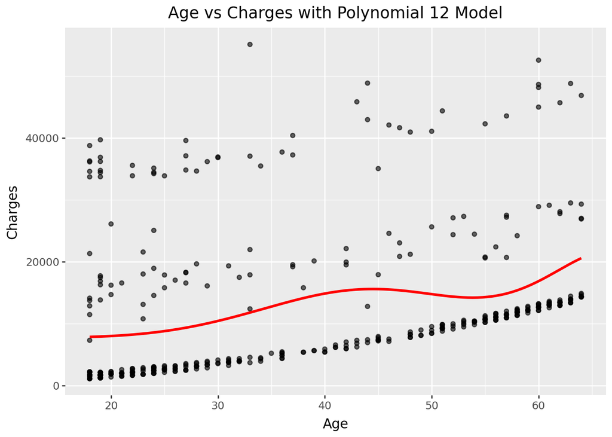

```python
x_pred = np.linspace(df['age'].min(), df['age'].max(), 200).reshape(-1, 1)

X_pred_poly12 = poly_features_12.transform(x_pred)
y_pred_poly12 = Poly12_Model.predict(X_pred_poly12)

reg12_df = pd.DataFrame({'age': x_pred.flatten(), 'charges_pred': y_pred_poly12})

(
    ggplot(df, aes(x='age', y='charges'))
    + geom_point(alpha=0.6)
    + geom_line(reg12_df, aes(x='age', y='charges_pred'), color='red', size=1.2)
    + labs(title="Age vs Charges with Polynomial 12 Model",x="Age", y="Charges")
)
```

# Part Four: New Data

```python
df2 = pd.read_csv("https://www.dropbox.com/s/sky86agc4s8c6qe/insurance_costs_2.csv?dl=1")
df2['smoking'] = df2['smoker'].map({'yes': 1, 'no': 0})
df2['male'] = df2['sex'].map({'male': 1, 'female': 0})
df2.head()
```

|  | age | sex | bmi | smoker | region | charges | smoking | male |
| --- | --- | --- | --- | --- | --- | --- | --- | --- |
| 0 | 23 | male | 34.400 | no | southwest | 1826.84300 | 0 | 1 |
| 1 | 56 | male | 40.300 | no | southwest | 10602.38500 | 0 | 1 |
| 2 | 18 | male | 34.100 | no | southeast | 1137.01100 | 0 | 1 |
| 3 | 63 | female | 23.085 | no | northeast | 14451.83515 | 0 | 0 |
| 4 | 63 | male | 28.310 | no | northwest | 13770.09790 | 0 | 1 |

## Creating New Models

```python
M1 = LinearRegression().fit(df[['age']], df['charges'])
pred1 = M1.predict(df2[['age']])
mse1 = mean_squared_error(df2['charges'], pred1)
r2_1 = r2_score(df2['charges'], pred1)

M2 = LinearRegression().fit(df[['age', 'bmi']], df['charges'])
pred2 = M2.predict(df2[['age', 'bmi']])
mse2 = mean_squared_error(df2['charges'], pred2)
r2_2 = r2_score(df2['charges'], pred2)

M3 = LinearRegression().fit(df[['age', 'bmi', 'smoking']], df['charges'])
pred3 = M3.predict(df2[['age', 'bmi', 'smoking']])
mse3 = mean_squared_error(df2['charges'], pred3)
r2_3 = r2_score(df2['charges'], pred3)

df['age_smoker'] = df['age'] * df['smoking']
df['bmi_smoker'] = df['bmi'] * df['smoking']
df2['age_smoker'] = df2['age'] * df2['smoking']
df2['bmi_smoker'] = df2['bmi'] * df2['smoking']

M4 = LinearRegression().fit(df[['age', 'bmi', 'age_smoker', 'bmi_smoker']], df['charges'])
pred4 = M4.predict(df2[['age', 'bmi', 'age_smoker', 'bmi_smoker']])
mse4 = mean_squared_error(df2['charges'], pred4)
r2_4 = r2_score(df2['charges'], pred4)

M5 = LinearRegression().fit(df[['age', 'bmi', 'smoking', 'age_smoker', 'bmi_smoker']], df['charges'])
pred5 = M5.predict(df2[['age', 'bmi', 'smoking', 'age_smoker', 'bmi_smoker']])
mse5 = mean_squared_error(df2['charges'], pred5)
r2_5 = r2_score(df2['charges'], pred5)
```

## MSEs and R2

```python
results_df = pd.DataFrame({
    'Model': [
        'Model 1: age',
        'Model 2: age + bmi',
        'Model 3: age + bmi + smoker',
        'Model 4: (age + bmi):smoker',
        'Model 5: (age + bmi)*smoker'
    ],
    'MSE (new data)': [mse1, mse2, mse3, mse4, mse5],
    'R² (new data)': [r2_1, r2_2, r2_3, r2_4, r2_5]
})

results_df['MSE (new data)'] = results_df['MSE (new data)'].apply(lambda x: f"{x:,.2f}")
results_df['R² (new data)'] = results_df['R² (new data)'].round(3)

results_df
```

|  | Model | MSE (new data) | R² (new data) |
| --- | --- | --- | --- |
| 0 | Model 1: age | 136,077,136.50 | 0.122 |
| 1 | Model 2: age + bmi | 132,636,406.11 | 0.145 |
| 2 | Model 3: age + bmi + smoker | 35,377,541.24 | 0.772 |
| 3 | Model 4: (age + bmi):smoker | 24,795,908.41 | 0.840 |
| 4 | Model 5: (age + bmi)*smoker | 21,786,256.87 | 0.859 |

Based on the MSE, model 5 which includes (Age + BMI) * Smoker is the model that best predicts Medical Charges

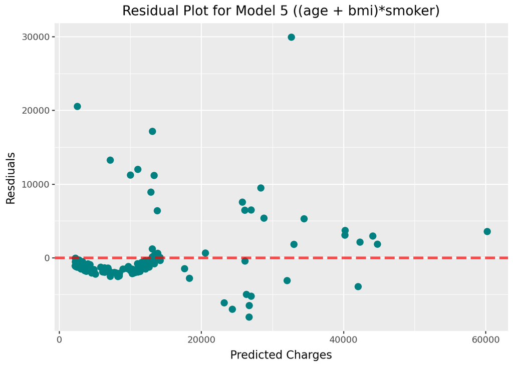

```python
pred5 = M5.predict(df2[['age', 'bmi', 'smoking', 'age_smoker', 'bmi_smoker']])
residuals = df2['charges'] - pred5

residuals_df = df2.copy()
residuals_df['predicted'] = pred5
residuals_df['residual'] = residuals

(
ggplot(residuals_df, aes(x='predicted', y='residual'))
+ geom_point(color='teal',size=3)
+ geom_hline(yintercept=0, color='red', linetype='dashed',size=1.5,alpha=0.7)
+ labs(title='Residual Plot for Model 5 ((age + bmi)*smoker)',x='Predicted Charges',y='Resdiuals')
)
```

# Part Five: Full Exploration

## Baseline Model to compare

```python
test_model = LinearRegression()
test_model.fit(df[["age", "bmi", "smoking", "male"]], df["charges"])

y_pred = test_model.predict(df2[["age", "bmi", "smoking", "male"]])

mse_test = mean_squared_error(df2["charges"], y_pred)
r2_test = r2_score(df2["charges"], y_pred)

print(f"MSE: {mse_test:,.2f}")
print(f"R²: {r2_test:.3f}")
```

```
MSE: 35,467,887.91
R²: 0.771
```

## Find optimal number of polynomials to maximize R-squared

```python
features = ['age', 'bmi', 'smoking', 'male']

results = []

for d in range(1, 6):

    poly = PolynomialFeatures(degree=d, include_bias=False)
    X_train = poly.fit_transform(df[features])
    X_test = poly.transform(df2[features])


    model = LinearRegression()
    model.fit(X_train, df['charges'])


    y_pred = model.predict(X_test)


    mse = mean_squared_error(df2['charges'], y_pred)
    r2 = r2_score(df2['charges'], y_pred)

    results.append((d, mse, r2))

results_df = pd.DataFrame(results, columns=['Degree', 'MSE', 'R²'])
results_df['MSE'] = results_df['MSE'].apply(lambda x: f"{x:,.2f}")
results_df['R²'] = results_df['R²'].round(3)
results_df
```

|  | Degree | MSE | R² |
| --- | --- | --- | --- |
| 0 | 1 | 35,467,887.91 | 0.771 |
| 1 | 2 | 21,549,294.36 | 0.861 |
| 2 | 3 | 22,065,929.07 | 0.858 |
| 3 | 4 | 25,361,752.15 | 0.836 |
| 4 | 5 | 30,766,927.67 | 0.802 |

Based on R2 and MSE we should use a 2-degree polynomial model

## Optimal Model based on 2 degrees

```python
poly_features = PolynomialFeatures(degree=2, include_bias=False)
X_train = poly_features.fit_transform(df[['age', 'bmi', 'smoking', 'male']])
X_test = poly_features.transform(df2[['age', 'bmi', 'smoking', 'male']])

best_model = LinearRegression()
best_model.fit(X_train, df['charges'])


y_pred_best = best_model.predict(X_test)

mse_best = mean_squared_error(df2['charges'], y_pred_best)
r2_best = r2_score(df2['charges'], y_pred_best)

print(f"MSE: {mse_best:,.2f}")
print(f"R²: {r2_best:.3f}")
```

```
MSE: 21,549,294.36
R²: 0.861
```

```python
feature_names = poly_features.get_feature_names_out(['age', 'bmi', 'smoking', 'male'])


names = ['Intercept'] + list(feature_names)

values = [best_model.intercept_] + list(best_model.coef_)

best_model_df = pd.DataFrame(values, index=names, columns=[0]).round(2)
best_model_df.index.name = "Optimal Model"
best_model_df
```

| Optimal Model | 0 |
| --- | --- |
| Intercept | -5345.83 |
| age | 108.61 |
| bmi | 391.12 |
| smoking | -10813.00 |
| male | -368.69 |
| age^2 | 1.47 |
| age bmi | 0.71 |
| age smoking | -16.88 |
| age male | 26.41 |
| bmi^2 | -6.62 |
| bmi smoking | 1504.09 |
| bmi male | -23.57 |
| smoking^2 | -10813.00 |
| smoking male | 279.41 |
| male^2 | -368.69 |

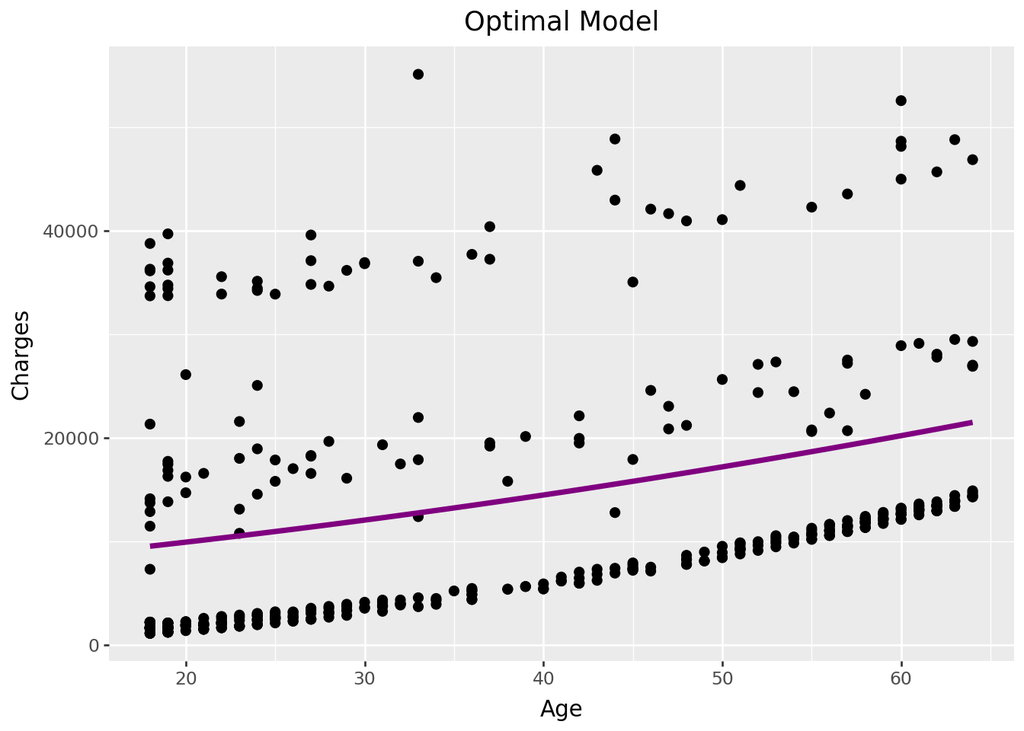

```python
features = ['age', 'bmi', 'smoking', 'male']

x_pred = np.linspace(df['age'].min(), df['age'].max(), 100)
reg_best_df = pd.DataFrame({
    'age': x_pred,
    'bmi': df['bmi'].mean(),
    'smoking': df['smoking'].mean(),
    'male': df['male'].mean()
})

X_plot = poly_features.transform(reg_best_df[features])


reg_best_df['charges_pred'] = best_model.predict(X_plot)

(
    ggplot(df, aes(x='age', y='charges'))
    + geom_point(color='black', size=2)
    + geom_line(reg_best_df, aes(x='age', y='charges_pred'), color='purple', size=1.5)
    + labs(title='Optimal Model', x='Age', y='Charges')
)
```

## Residual plot of best model

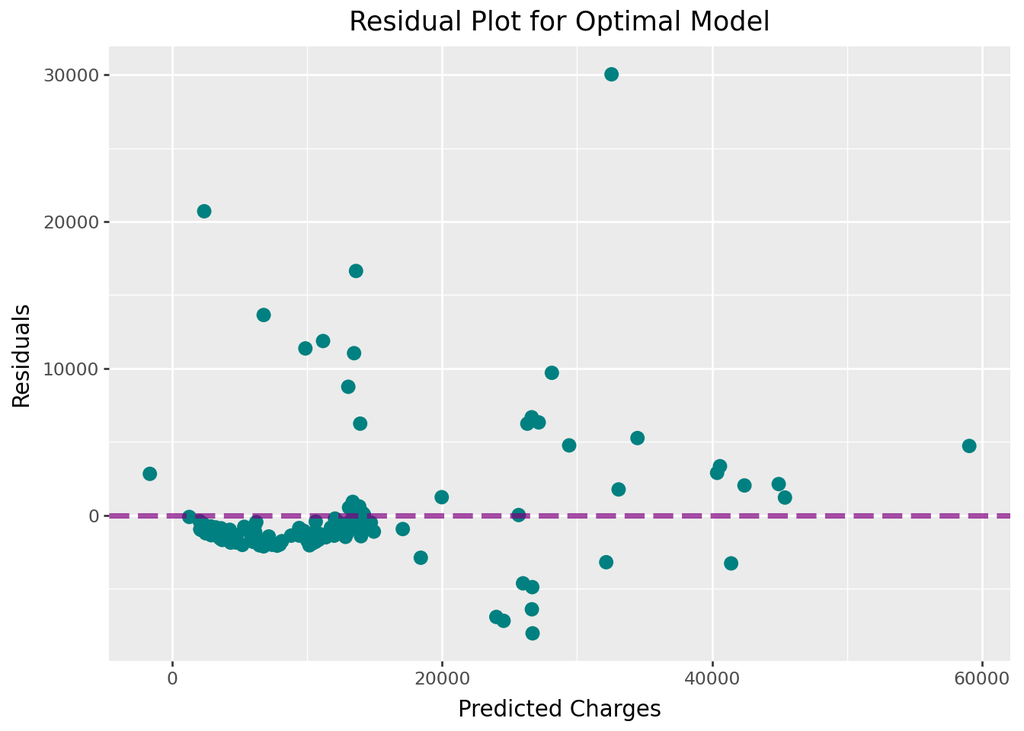

```python
residuals_df = df2.copy()
residuals_df['predicted'] = y_pred_best
residuals_df['residuals'] = residuals_df['charges'] - residuals_df['predicted']

(
    ggplot(residuals_df, aes(x='predicted', y='residuals'))
    + geom_point(color='teal',size=3)
    + geom_hline(yintercept=0, color='purple', linetype='dashed',size=1.5,alpha=0.7)
    + labs(title='Residual Plot for Optimal Model',x='Predicted Charges',y='Residuals')
)
```